# Data 607 Assignment 1

2024-09-04

# Assignment – Loading Data into a Data Frame

We are often tasked with taking data in one form and transforming it for easier downstream analysis. We will spend several weeks in this course on tidying and transformation operations. Some of this work could be done in SQL or R (or Python or…). Here, you are asked to use R—you may use any base functions or packages as you like. Your task is to first choose one of the provided datasets on fivethirtyeight.com that you find interesting: https://data.fivethirtyeight.com/ You should first study the data and any other information on the GitHub site, and read the associated fivethirtyeight.com article. To receive full credit, you should: 1. Take the data, and create one or more code blocks. You should finish with a data frame that contains a subset of the columns in your selected dataset. If there is an obvious target (aka predictor or independent) variable, you should include this in your set of columns. You should include (or add if necessary) meaningful column names and replace (if necessary) any non-intuitive abbreviations used in the data that you selected. For example, if you had instead been tasked with working with the UCI mushroom dataset, you would include the target column for edible or poisonous, and transform “e” values to “edible.” Your deliverable is the R code to perform these transformation tasks. 2. Make sure that the original data file is accessible through your code—for example, stored in a GitHub repository or AWS S3 bucket and referenced in your code. If the code references data on your local machine, then your work is not reproducible! 3. Start your R Markdown document with a two to three sentence “Overview” or “Introduction” description of what the article that you chose is about, and include a link to the article. 4. Finish with a “Conclusions” or “Findings and Recommendations” text block that includes what you might do to extend, verify, or update the work from the selected article. 5. Each of your text blocks should minimally include at least one header, and additional non-header text. 6. You’re of course welcome—but not required–to include additional information, such as exploratory data analysis graphics (which we will cover later in the course). 7. Place your solution into a single R Markdown (.Rmd) file and publish your solution out to rpubs.com. 8. Post the .Rmd file in your GitHub repository, and provide the appropriate URLs to your GitHub repository and your rpubs.com file in your assignment link.

# Overview

The article “Congress Today Is Older Than It’s Ever Been” by Geoffrey Skelley explores the significant aging trend within Congress, noting that it is currently older than ever before, with a median age of 59 years for the 118th Congress. The median age of senators is 65, and representatives stand at 58. The shift towards an older Congress affects policy attention, potentially sidelining younger concerns like climate change and affordable housing. Historical data shows a rising median age over the decades, influenced by longer life expectancies and political factors. However, as baby boomers eventually retire, there may be a gradual shift in Congress’s age composition with increased representation from younger generations like Gen X, millennials, and Gen Z, potentially leading to a more balanced legislative focus.

Article: https://fivethirtyeight.com/features/aging-congress-boomers/ Datasource: https://data.fivethirtyeight.com/

## Data Preparation

```r
library(tidyverse)
library(dplyr)
```

```r
congress_age_data <- read.csv('https://raw.githubusercontent.com/ErickH1/DATA607Assignment1/main/congress-demographics/data_aging_congress.csv')
```

Subsetting dataframe without extra information and rounding the age_years to the nearest whole

```r
congress_age_subset <- subset(congress_age_data, congress == "118", select = c('chamber','party_code','age_years','generation'))
congress_age_subset$age_years <- round(congress_age_subset$age_years, digits = 0)
```

Subsetting based on position

```r
congress_age_house <- subset(congress_age_subset, chamber == "House", select = c('chamber','party_code','age_years','generation'))
congress_age_subset$age_years <- round(congress_age_subset$age_years, digits = 0)
congress_age_senate <- subset(congress_age_subset, chamber == "Senate", select = c('chamber','party_code','age_years','generation'))
congress_age_subset$age_years <- round(congress_age_subset$age_years, digits = 0)
```

Subsetting based on party

```r
congress_age_dem <- subset(congress_age_subset, party_code == "100", select = c('chamber','party_code','age_years','generation'))
congress_age_subset$age_years <- round(congress_age_subset$age_years, digits = 0)
congress_age_rep <- subset(congress_age_subset, party_code == "200", select = c('chamber','party_code','age_years','generation'))
congress_age_subset$age_years <- round(congress_age_subset$age_years, digits = 0)
congress_age_ind <- subset(congress_age_subset, party_code == "328", select = c('chamber','party_code','age_years','generation'))
congress_age_subset$age_years <- round(congress_age_subset$age_years, digits = 0)
```

## Summarize the Data

Summary of the dataset

```r
glimpse(congress_age_subset)
```

```
## Rows: 536
## Columns: 4
## $ chamber    <chr> "House", "House", "House", "House", "House", "House", "Hous…
## $ party_code <int> 200, 100, 200, 100, 100, 200, 200, 100, 200, 200, 100, 100,…
## $ age_years  <dbl> 57, 35, 65, 77, 44, 71, 51, 40, 46, 59, 76, 74, 71, 49, 36,…
## $ generation <chr> "Gen X", "Millennial", "Boomers", "Boomers", "Gen X", "Boom…
```

Summary of the dataset mean age is 59 years

```r
summary(congress_age_subset)
```

```
##    chamber            party_code    age_years      generation
##  Length:536         Min.   :100   Min.   :26.00   Length:536
##  Class :character   1st Qu.:100   1st Qu.:49.00   Class :character
##  Mode  :character   Median :200   Median :59.00   Mode  :character
##                     Mean   :152   Mean   :58.56
##                     3rd Qu.:200   3rd Qu.:68.00
##                     Max.   :328   Max.   :90.00
```

Summary of subset based on party

```r
summary(congress_age_dem)
```

```
##    chamber            party_code    age_years     generation
##  Length:261         Min.   :100   Min.   :26.0   Length:261
##  Class :character   1st Qu.:100   1st Qu.:49.0   Class :character
##  Mode  :character   Median :100   Median :60.0   Mode  :character
##                     Mean   :100   Mean   :59.4
##                     3rd Qu.:100   3rd Qu.:70.0
##                     Max.   :100   Max.   :90.0
```

```r
summary(congress_age_rep)
```

```
##    chamber            party_code    age_years      generation
##  Length:272         Min.   :200   Min.   :34.00   Length:272
##  Class :character   1st Qu.:200   1st Qu.:49.00   Class :character
##  Mode  :character   Median :200   Median :59.00   Mode  :character
##                     Mean   :200   Mean   :57.64
##                     3rd Qu.:200   3rd Qu.:66.00
##                     Max.   :200   Max.   :89.00
```

```r
summary(congress_age_ind)
```

```
##    chamber            party_code    age_years      generation
##  Length:3           Min.   :328   Min.   :46.00   Length:3
##  Class :character   1st Qu.:328   1st Qu.:62.50   Class :character
##  Mode  :character   Median :328   Median :79.00   Mode  :character
##                     Mean   :328   Mean   :68.67
##                     3rd Qu.:328   3rd Qu.:80.00
##                     Max.   :328   Max.   :81.00
```

Summary of subset based in position

```r
summary(congress_age_house)
```

```
##    chamber            party_code    age_years      generation
##  Length:435         Min.   :100   Min.   :26.00   Length:435
##  Class :character   1st Qu.:100   1st Qu.:47.00   Class :character
##  Mode  :character   Median :200   Median :58.00   Mode  :character
##                     Mean   :151   Mean   :57.31
##                     3rd Qu.:200   3rd Qu.:67.00
##                     Max.   :200   Max.   :86.00
```

```r
summary(congress_age_senate)
```

```
##    chamber            party_code      age_years      generation
##  Length:101         Min.   :100.0   Min.   :36.00   Length:101
##  Class :character   1st Qu.:100.0   1st Qu.:56.00   Class :character
##  Mode  :character   Median :200.0   Median :65.00   Mode  :character
##                     Mean   :156.3   Mean   :63.91
##                     3rd Qu.:200.0   3rd Qu.:71.00
##                     Max.   :328.0   Max.   :90.00
```

## Data Visualiztion

In this section graphs will visualize the distribution of ages throughout the subsets. Graph of the Generation

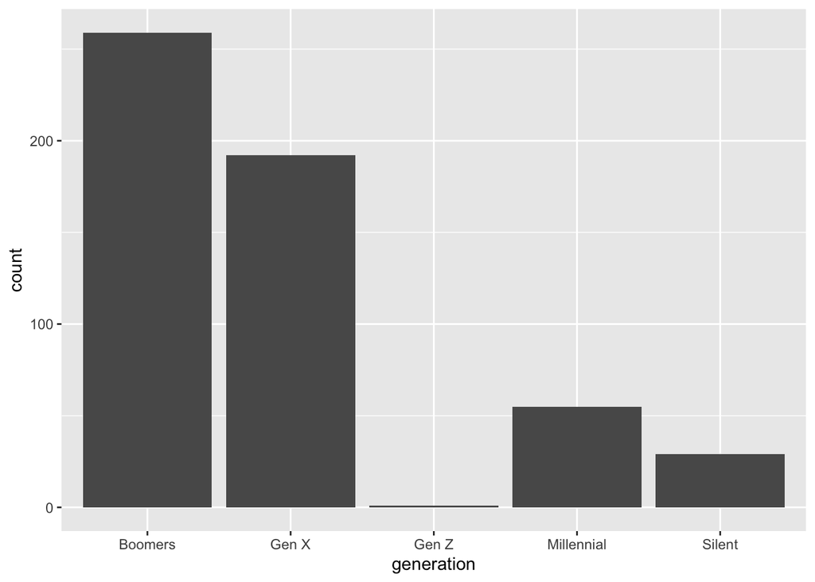

```r
ggplot(data = congress_age_subset, aes(x = generation)) +
  geom_bar()
```

Graph of the Age distribution

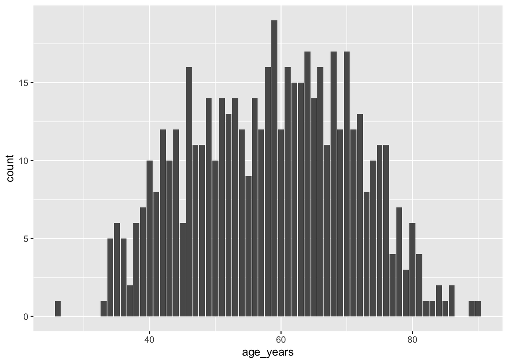

```r
ggplot(data = congress_age_subset, aes(x = age_years)) +
  geom_bar()
```

Graph of the Age distribution based on House

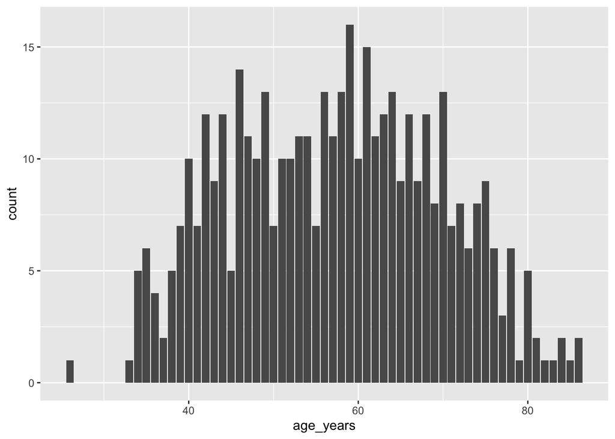

```r
ggplot(data = congress_age_house, aes(x = age_years)) +
  geom_bar()
```

Graph of the Age distribution based on Senate

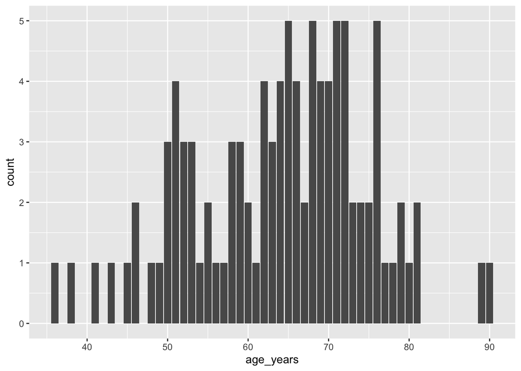

```r
ggplot(data = congress_age_senate, aes(x = age_years)) +
  geom_bar()
```

Graph of the Age distribution based on Democrat

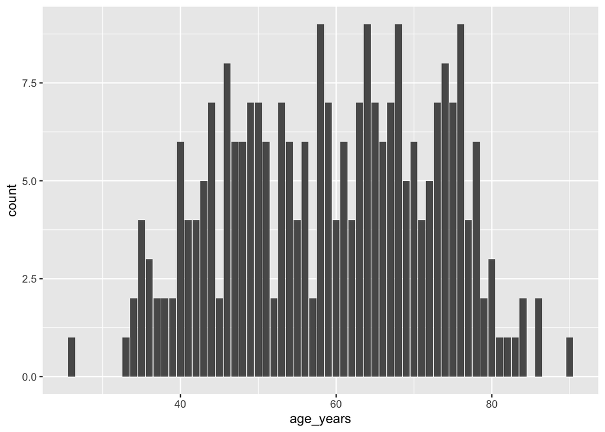

```r
ggplot(data = congress_age_dem, aes(x = age_years)) +
  geom_bar()
```

Graph of the Age distribution based on Republican

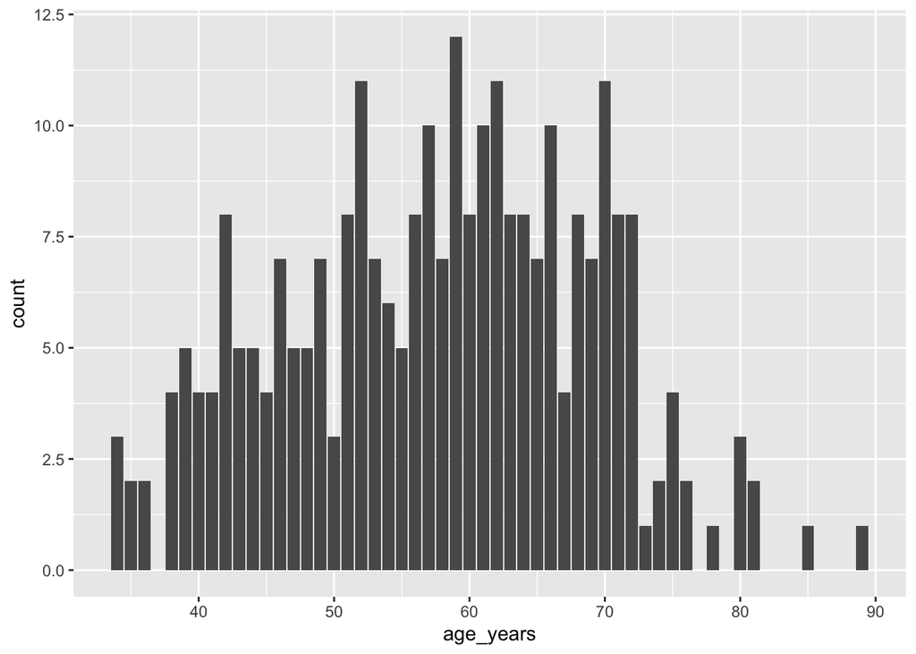

```r
ggplot(data = congress_age_rep, aes(x = age_years)) +
  geom_bar()
```

Graph of the Age distribution based on Independent

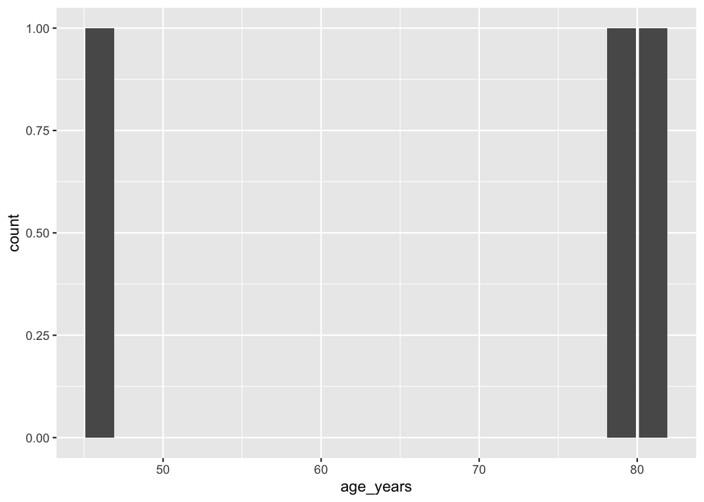

```r
ggplot(data = congress_age_ind, aes(x = age_years)) +
  geom_bar()
```